# Assignment 2

Chloe Moore

2024-10-15

```r
library(tidyverse)
library(ggplot2)
```

### Question 11. Exercise 2.20

```r
nursing_homeDF = read.csv("WiscNursingHome.csv")
nursing_home2001 = subset(nursing_homeDF, CRYEAR == 2001) %>%
  mutate(
    LOGTPY = log(TPY),
    LOGNUMBED = log(NUMBED)
  )
```

#### Part a)

```r
summary(nursing_home2001$LOGTPY) # summary statistics LOGTPY
```

```
##    Min. 1st Qu.  Median    Mean 3rd Qu.    Max.
##   2.511   4.041   4.396   4.368   4.700   6.088
```

```r
summary(nursing_home2001$LOGNUMBED) # summary statistics LOGNUMBED
```

```
##    Min. 1st Qu.  Median    Mean 3rd Qu.    Max.
##   2.890   4.094   4.500   4.457   4.779   6.125
```

```r
cor(nursing_home2001$LOGTPY, nursing_home2001$LOGNUMBED) # correlation statistic
```

```
## [1] 0.9830461
```

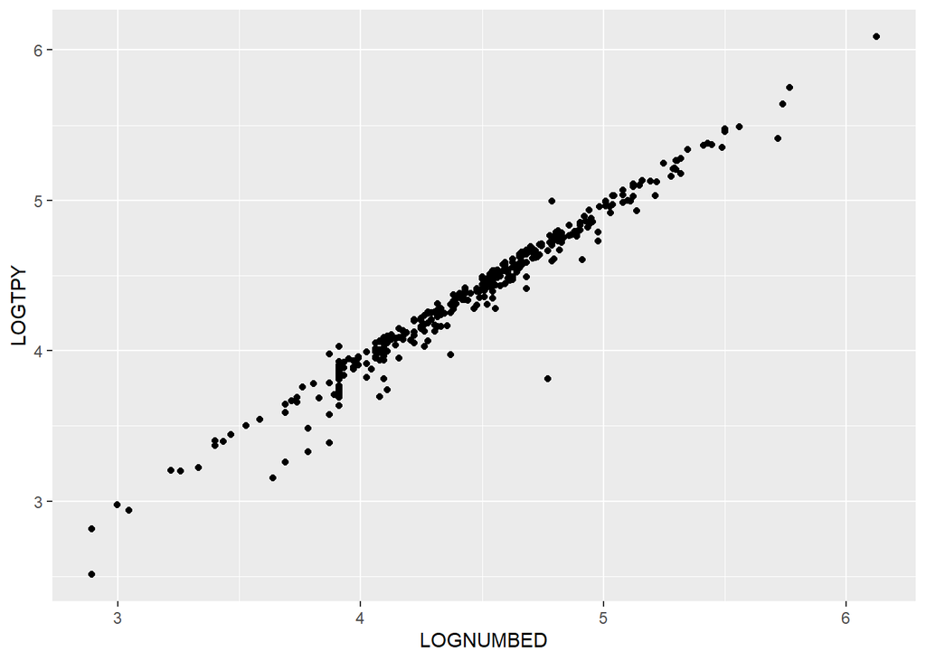

```r
ggplot(nursing_home2001, aes(x=LOGNUMBED, y=LOGTPY)) +
  geom_point()
```

Comments: The correlation statistic is very close to 1, which indicates LOGTPY and LOGNUMBED are closely, positively correlated. The scatter plot chart appears to show a linear trend.

#### Part b)

```r
fit1 = lm(LOGTPY ~ LOGNUMBED, nursing_home2001)
summary1 = summary(fit1)
summary1
```

```
##
## Call:
## lm(formula = LOGTPY ~ LOGNUMBED, data = nursing_home2001)
##
## Residuals:
##      Min       1Q   Median       3Q      Max
## -0.87482 -0.02201  0.01517  0.05316  0.28862
##
## Coefficients:
##             Estimate Std. Error t value Pr(>|t|)
## (Intercept) -0.17469    0.04537   -3.85  0.00014 ***
## LOGNUMBED    1.01923    0.01012  100.73  < 2e-16 ***
## ---
## Signif. codes:  0 '***' 0.001 '**' 0.01 '*' 0.05 '.' 0.1 ' ' 1
##
## Residual standard error: 0.09373 on 353 degrees of freedom
## Multiple R-squared:  0.9664, Adjusted R-squared:  0.9663
## F-statistic: 1.015e+04 on 1 and 353 DF,  p-value: < 2.2e-16
```

Comments: R^2 = 0.9664 (adjusted R^2=0.9663). Regression coefficient LOGNUMBED = 1.01923. t-statistic = 100.73

#### Part c)

```r
b1 = summary1$coefficients[2, 1]
seb1 = summary1$coefficients[2, 2]
tcrit = 2 # for t_(353, 0.975)
```

(I) $H_0:\beta_{1}=0$ vs $H_a:\beta_{1}\ne0$. We reject the null hypothesis because our t-statistic is greater than the critical t-value. The p-value is less than our alpha level of 0.05, which supports this rejection.

```r
tstat = b1/seb1 # 100.730193
pval = 2*(1-pt(abs(tstat), 353)) # 0.0000000...
```

(II) $H_0:\beta_{1}=1$ vs $H_a:\beta_{1}\ne1$. We fail to reject the null hypothesis because our t-statistic is less than the critical t-value (however, it’s very close!). The p-value is greater than our alpha level of 0.05, which supports this conclusion.

```r
tstat = (b1-1)/seb1 # 1.900567
pval = 2*(1-pt(abs(tstat), 353)) # 0.058173
```

(III) $H_0:\beta_{1}=1$ vs $H_a:\beta_{1}>1$. We might fail to reject the null hypothesis because our t-statistic is less than the critical t-value… But the p-value is less than our alpha level of 0.05, so in this case, we will actually reject the null hypothesis.

```r
tstat = (b1-1)/seb1 # 1.900567
pval = (1-pt(abs(tstat), 353)) # 0.029087
```

(IV) $H_0:\beta_{1}=1$ vs $H_a:\beta_{1}<1$. We might fail to reject the null hypothesis because our t-statistic is less than the critical t-value… And the p-value is greater than our alpha level of 0.05, so we will indeed fail to reject the null hypothesis.

```r
tstat = (b1-1)/seb1 # 1.900567
pval = pt(abs(tstat), 353) # 0.970913
```